# act_report

## Project 4 - Data Analysis & Visualization (EDA) of the WeRateDogs

### Introduction

The goal of this report is to document the analysis and insights of the EDA applied in the WeRateDogs dataframe.

#### Data Analysis & Visualization

The first analysis is focused on the retweet and favorites count. The distribution below shows with the actual data and log Transformed data. The reason a transformation in the log was performed is to make the distribution plot to near normal distribution. The following plots shows that only very few tweets have higher Retweets and favorites, and majority of them fall into right tail distribution.

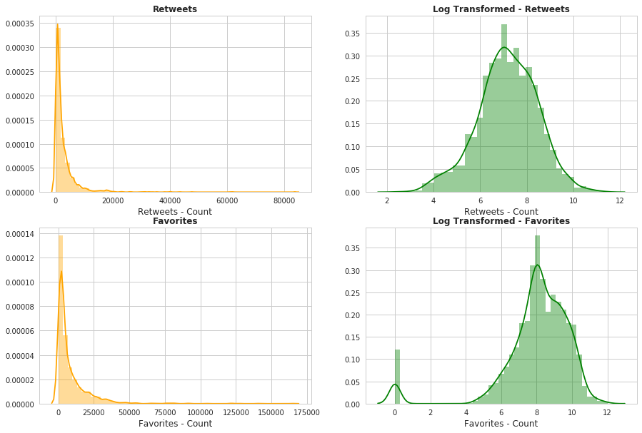

```python
from IPython.display import Image
Image(filename='RetweetsVSFavorites.png')
```

Next, a correlation analysis with the numeric attributes with a major focus on Favorites and Retweets were performed.

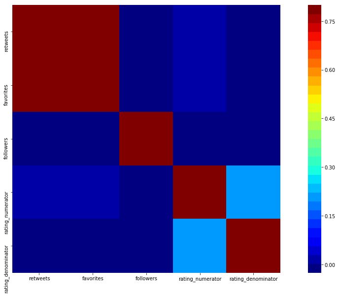

```python
from IPython.display import Image
Image(filename='Correlation_Plot.png')
```

Retweets and Favorites are highly correlated. This shows that people who have retweeted have also done with favorites tag. Hence both the distributions shows similar behaviour.

A scatter plot between Retweets and Favorites were made to confirm the correlation. It shows that they both follow a similar trend and go in sync together.

There is a very strong relationship between retweet and favorite counts. As the user shows interest on Favorites, one can expect to see Retweets to increase and vice-versa.

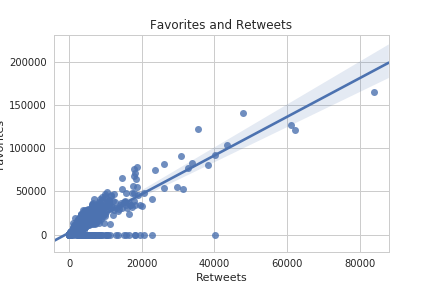

```python
from IPython.display import Image
Image(filename='Scatterplot.png')
```

The twitter has changed. The "favorite" is now "like".

So from here, we can also interpret that most of the users do a like or favorite because it acts like a bookmark thing which can help them to review back again.

Retweets are not saved in the twitter profile. The above analysis above had helped me learn and created good awareness about the website and it also helped to learn about different types of dog breeds available in the world.

I have also looked at the image predictions output which shows the output produced from different algorithms.

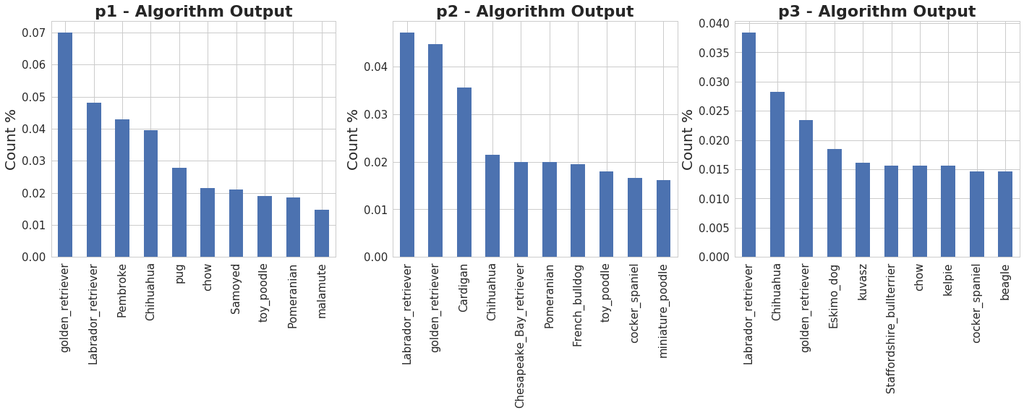

```python
from IPython.display import Image
Image(filename='Predictions_Output.png')
```

- Most of the predictions done by 3 algorithms is done for golden_retriever, Labrador_retriever and Chihuahua dogs.

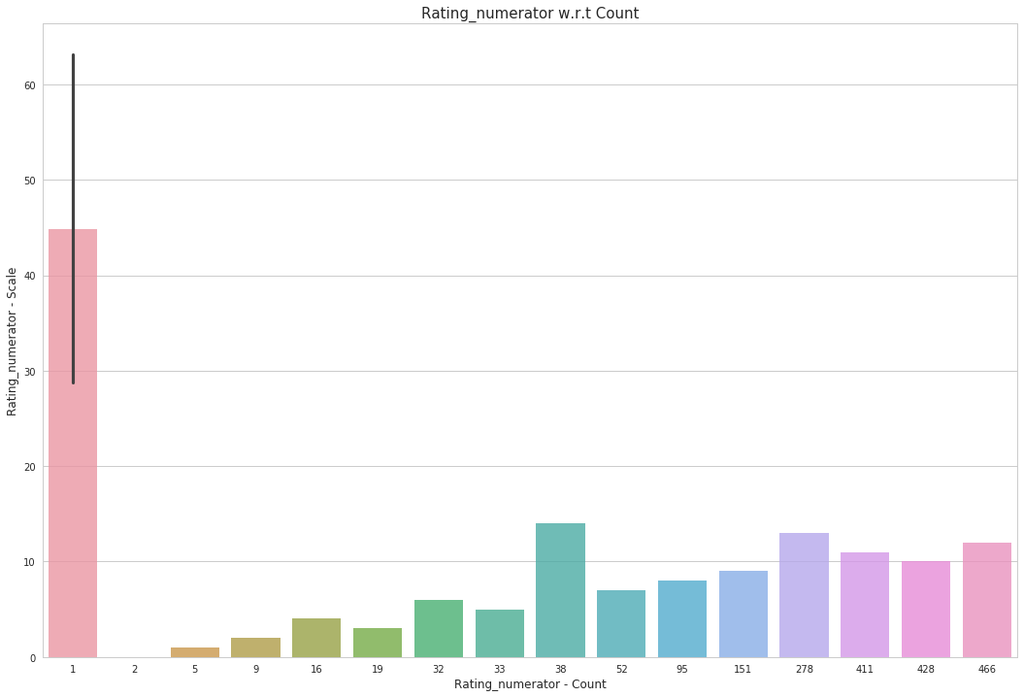

```python
from IPython.display import Image
Image(filename='Rating_numerator.png')
```

- Rating numerator have majority of the ratings around 10.

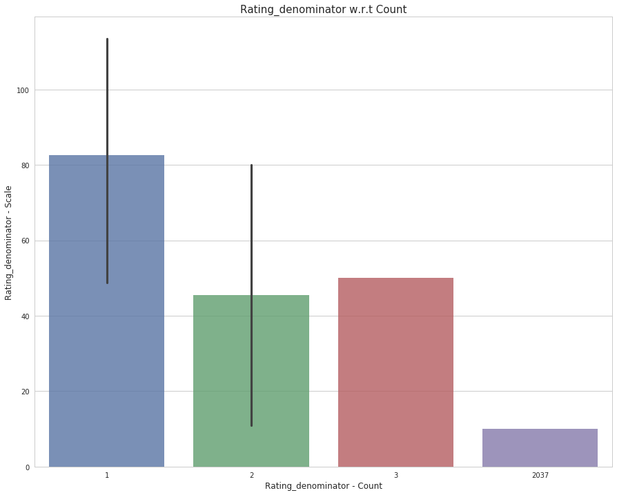

```python
from IPython.display import Image
Image(filename='Rating_denominator.png')
```

- Generally, there must be rating denominator with only 10, but sometimes users with exaggeration may be rated with < 10 and > 10.
- So, overall we have 16 records with the above scenario and all other tweets are rated on 10
- 2037 tweets have 10 rating